# Red Wine Quality Data Analysis

#### Udacity Data Analyst Nanodegree

#### P4: Explore and Summarize Data

#### October’2016

# About the Dataset

This dataset is public available for research. The details are described in [Cortez et al., 2009]. P. Cortez, A. Cerdeira, F. Almeida, T. Matos and J. Reis. Modeling wine preferences by data mining from physicochemical properties. In Decision Support Systems, Elsevier, 47(4):547-553. ISSN: 0167-9236.

Available at:

1. [Elsevier](http://dx.doi.org/10.1016/j.dss.2009.05.016)
2. [Pre-press (pdf)](http://www3.dsi.uminho.pt/pcortez/winequality09.pdf)
3. bib

# Objective of the Analysis

Prediction of the quality ranking by tasters from the various measured properties of red wines to guide grape growers and wine producers regarding a wine quality.

# Data Overview

#### Variable description:

Input Variables:

1. fixed acidity: most acids involved with wine or fixed or nonvolatile (do not evaporate readily)
2. volatile acidity: the amount of acetic acid in wine, which at too high of levels can lead to an unpleasant, vinegar taste
3. citric acid: found in small quantities, citric acid can add ‘freshness’ and flavor to wines
4. residual sugar: the amount of sugar remaining after fermentation stops, it’s rare to find wines with less than 1 gram/liter and wines with greater than 45 grams/liter are considered sweet
5. chlorides: the amount of salt in the wine
6. free sulfur dioxide: the free form of SO2 exists in equilibrium between molecular SO2 (as a dissolved gas) and bisulfite ion; it prevents microbial growth and the oxidation of wine
7. total sulfur dioxide: amount of free and bound forms of S02; in low concentrations, SO2 is mostly undetectable in wine, but at free SO2 concentrations over 50 ppm, SO2 becomes evident in the nose and taste of wine
8. density: the density of water is close to that of water depending on the percent alcohol and sugar content
9. pH: describes how acidic or basic a wine is on a scale from 0 (very acidic) to 14 (very basic); most wines are between 3-4 on the pH scale
10. sulphates: a wine additive which can contribute to sulfur dioxide gas (S02) levels, wich acts as an antimicrobial and antioxidant
11. alcohol: the percent alcohol content of the wine

Output Variable (based on sensory data):

12. quality (score between 0 and 10)

#### Quick view of the statistics:

The dimension of the red wine dataset.

```
## [1] 1599   13
```

Descriptive statistics of every variable in the dataset.

```
##                   fixed.acidity   volatile.acidity  citric.acid
##  Min.   :   1.0   Min.   : 4.60   Min.   :0.1200   Min.   :0.000
##  1st Qu.: 400.5   1st Qu.: 7.10   1st Qu.:0.3900   1st Qu.:0.090
##  Median : 800.0   Median : 7.90   Median :0.5200   Median :0.260
##  Mean   : 800.0   Mean   : 8.32   Mean   :0.5278   Mean   :0.271
##  3rd Qu.:1199.5   3rd Qu.: 9.20   3rd Qu.:0.6400   3rd Qu.:0.420
##  Max.   :1599.0   Max.   :15.90   Max.   :1.5800   Max.   :1.000
##  residual.sugar     chlorides       free.sulfur.dioxide
##  Min.   : 0.900   Min.   :0.01200   Min.   : 1.00
##  1st Qu.: 1.900   1st Qu.:0.07000   1st Qu.: 7.00
##  Median : 2.200   Median :0.07900   Median :14.00
##  Mean   : 2.539   Mean   :0.08747   Mean   :15.87
##  3rd Qu.: 2.600   3rd Qu.:0.09000   3rd Qu.:21.00
##  Max.   :15.500   Max.   :0.61100   Max.   :72.00
##  total.sulfur.dioxide    density             pH          sulphates
##  Min.   :  6.00       Min.   :0.9901   Min.   :2.740   Min.   :0.3300
##  1st Qu.: 22.00       1st Qu.:0.9956   1st Qu.:3.210   1st Qu.:0.5500
##  Median : 38.00       Median :0.9968   Median :3.310   Median :0.6200
##  Mean   : 46.47       Mean   :0.9967   Mean   :3.311   Mean   :0.6581
##  3rd Qu.: 62.00       3rd Qu.:0.9978   3rd Qu.:3.400   3rd Qu.:0.7300
##  Max.   :289.00       Max.   :1.0037   Max.   :4.010   Max.   :2.0000
##     alcohol         quality
##  Min.   : 8.40   Min.   :3.000
##  1st Qu.: 9.50   1st Qu.:5.000
##  Median :10.20   Median :6.000
##  Mean   :10.42   Mean   :5.636
##  3rd Qu.:11.10   3rd Qu.:6.000
##  Max.   :14.90   Max.   :8.000
```

The information about the structure of dataframe, variable data types.

```
## 'data.frame':    1599 obs. of  13 variables:
##  $                     : int  1 2 3 4 5 6 7 8 9 10 ...
##  $ fixed.acidity       : num  7.4 7.8 7.8 11.2 7.4 7.4 7.9 7.3 7.8 7.5 ...
##  $ volatile.acidity    : num  0.7 0.88 0.76 0.28 0.7 0.66 0.6 0.65 0.58 0.5 ...
##  $ citric.acid         : num  0 0 0.04 0.56 0 0 0.06 0 0.02 0.36 ...
##  $ residual.sugar      : num  1.9 2.6 2.3 1.9 1.9 1.8 1.6 1.2 2 6.1 ...
##  $ chlorides           : num  0.076 0.098 0.092 0.075 0.076 0.075 0.069 0.065 0.073 0.071 ...
##  $ free.sulfur.dioxide : num  11 25 15 17 11 13 15 15 9 17 ...
##  $ total.sulfur.dioxide: num  34 67 54 60 34 40 59 21 18 102 ...
##  $ density             : num  0.998 0.997 0.997 0.998 0.998 ...
##  $ pH                  : num  3.51 3.2 3.26 3.16 3.51 3.51 3.3 3.39 3.36 3.35 ...
##  $ sulphates           : num  0.56 0.68 0.65 0.58 0.56 0.56 0.46 0.47 0.57 0.8 ...
##  $ alcohol             : num  9.4 9.8 9.8 9.8 9.4 9.4 9.4 10 9.5 10.5 ...
##  $ quality             : int  5 5 5 6 5 5 5 7 7 5 ...
```

Creating a subset, by removing first column - row id’s, and adding a column with the quality values as a factor type

```
## 'data.frame':    1599 obs. of  13 variables:
##  $ fixed.acidity       : num  7.4 7.8 7.8 11.2 7.4 7.4 7.9 7.3 7.8 7.5 ...
##  $ volatile.acidity    : num  0.7 0.88 0.76 0.28 0.7 0.66 0.6 0.65 0.58 0.5 ...
##  $ citric.acid         : num  0 0 0.04 0.56 0 0 0.06 0 0.02 0.36 ...
##  $ residual.sugar      : num  1.9 2.6 2.3 1.9 1.9 1.8 1.6 1.2 2 6.1 ...
##  $ chlorides           : num  0.076 0.098 0.092 0.075 0.076 0.075 0.069 0.065 0.073 0.071 ...
##  $ free.sulfur.dioxide : num  11 25 15 17 11 13 15 15 9 17 ...
##  $ total.sulfur.dioxide: num  34 67 54 60 34 40 59 21 18 102 ...
##  $ density             : num  0.998 0.997 0.997 0.998 0.998 ...
##  $ pH                  : num  3.51 3.2 3.26 3.16 3.51 3.51 3.3 3.39 3.36 3.35 ...
##  $ sulphates           : num  0.56 0.68 0.65 0.58 0.56 0.56 0.46 0.47 0.57 0.8 ...
##  $ alcohol             : num  9.4 9.8 9.8 9.8 9.4 9.4 9.4 10 9.5 10.5 ...
##  $ quality             : int  5 5 5 6 5 5 5 7 7 5 ...
##  $ quality.f           : Factor w/ 10 levels "1","2","3","4",..: 5 5 5 6 5 5 5 7 7 5 ...
```

# Univariate Plots Section

Creating histogram and bar plots to explore the distribution of the variable values.

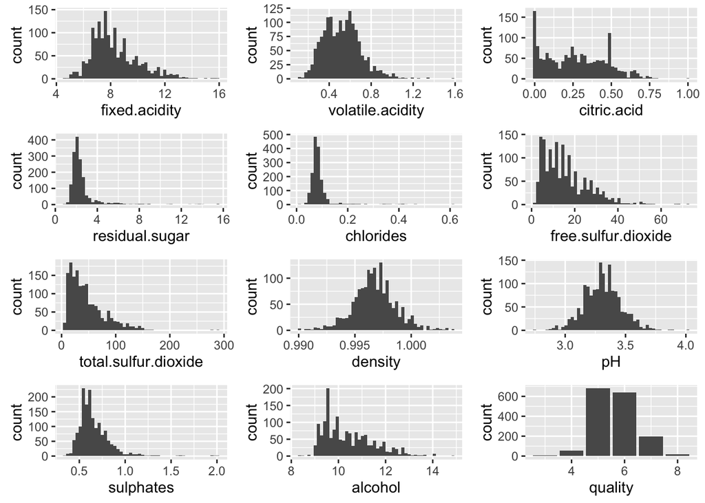

Creating boxplots for each of the variables.

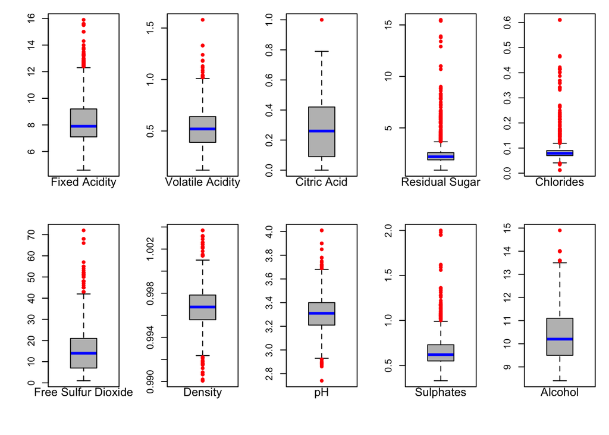

# Univariate Analysis

The dataset consists of 13 variables with 1599 observations. The column, which holds row ID, name is empty string, it will be re-named $row.ID$. There is an aditional variable $quality.f$ created as a factor of the quality scores. Two variables - $row.ID$ and $quality$ - are integer type, $quality.f$ - factor type, the rest are numeric type.

Due to privacy and logistic issues, only physicochemical (inputs) and sensory (the output) variables are available. There is no data about grape types, wine brand, wine selling price.

The main feature to explore is $quality.f$ which is quality ranking by wine testers. It is not clear if all predictor variables are relevant. So it could be interesting to test feature selection methods.

The summary of the dataset supports these observations. Mean is usually greater than the median. This indicate that there are outliers.

# Bivariate Plots Section

Scatterplot to pair up all input values with the main feature to explore - output variable $quality$.

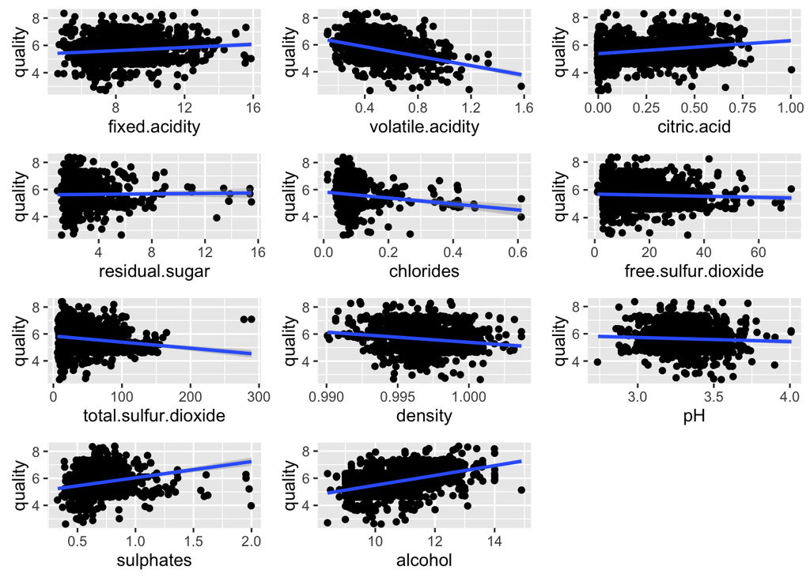

Pairwise comparison of variables of our dataset. It provides two different comparisons of each pair of columns and displays either the density or count of the respective variable along the diagonal.

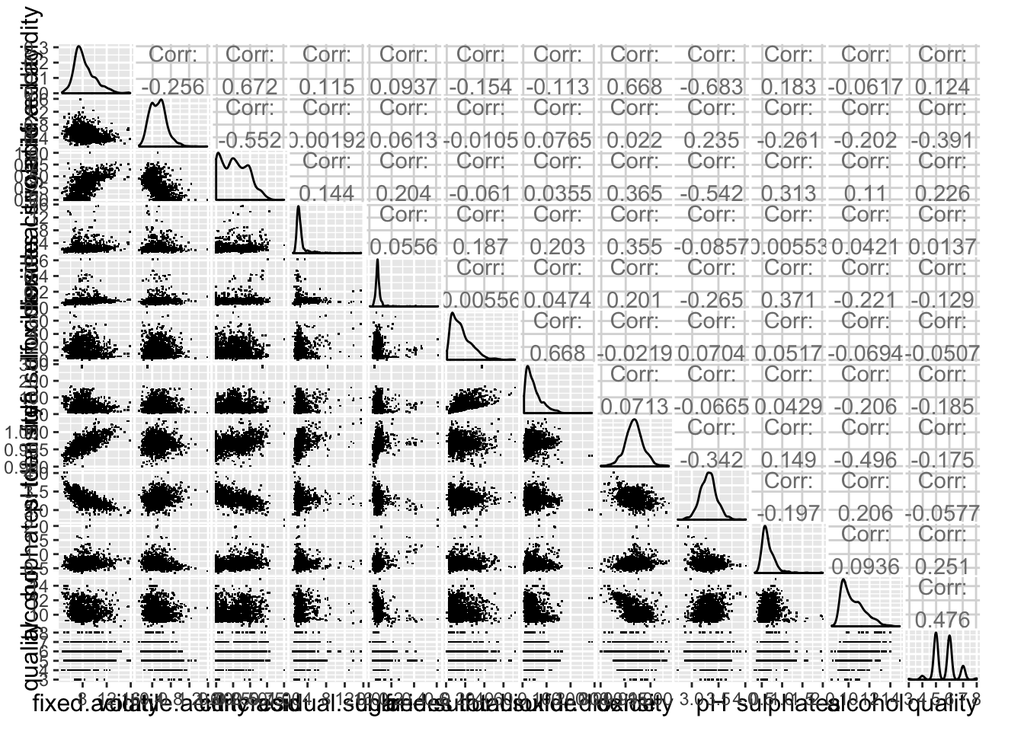

Scatterplot to pair up more interesting input values in the data set with added smoothed conditional mean, which helps in seeing patterns when overplotting.

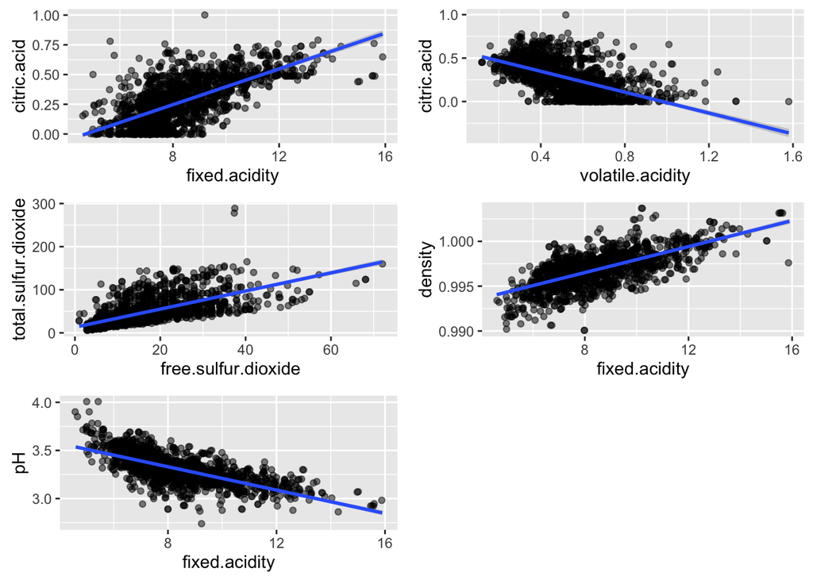

Correlation tests to confirm correlation between some more interesting values.

Table: Pearson’s Correlation

```
## # A tibble: 7 × 3
##         p.value         cor
##           <dbl>       <dbl>
## 1 4.063034e-220 -0.68297819
## 2 2.535321e-210  0.67170343
## 3 1.805663e-128 -0.55249568
## 4 6.404723e-207  0.66766645
## 5 3.074747e-207  0.66804729
## 6  9.258425e-02  0.04207544
## 7  2.831477e-91  0.47616632
## # ... with 1 more variables: pair <chr>
```

Table: Spearman Rank Correlation

```
## # A tibble: 7 × 3
##         p.value        rho
##           <dbl>      <dbl>
## 1 3.182584e-242 -0.7066736
## 2 5.385745e-202  0.6617084
## 3 9.013427e-164 -0.6102595
## 4  0.000000e+00  0.7896979
## 5 1.268199e-172  0.6230708
## 6  2.971850e-06  0.1165481
## 7  2.726838e-92  0.4785317
## # ... with 1 more variables: pair <chr>
```

# Bivariate Analysis

The scatterplot of all input values with the output variable $quality$ does reveal some information, but not enough to draw any conclusions.

# Multivariate Plots Section

Creating a Logistic Regression Model

```
##
## Call:  glm(formula = quality.f ~ fixed.acidity + volatile.acidity +
##     citric.acid + residual.sugar + chlorides + free.sulfur.dioxide +
##     total.sulfur.dioxide + density + pH + sulphates + alcohol,
##     family = binomial(link = "logit"), data = redwine)
##
## Coefficients:
##          (Intercept)         fixed.acidity      volatile.acidity
##            494.89510              -0.28791              -8.40765
##          citric.acid        residual.sugar             chlorides
##             -3.70698               0.14205             -13.03262
##  free.sulfur.dioxide  total.sulfur.dioxide               density
##             -0.15367               0.09925            -470.45027
##                   pH             sulphates               alcohol
##             -8.01302               2.69403               1.32310
##
## Degrees of Freedom: 1598 Total (i.e. Null);  1587 Residual
## Null Deviance:       121.4
## Residual Deviance: 69.17     AIC: 93.17
```

Checking, which features are significant.

```
##
## Call:
## glm(formula = quality.f ~ fixed.acidity + volatile.acidity +
##     citric.acid + residual.sugar + chlorides + free.sulfur.dioxide +
##     total.sulfur.dioxide + density + pH + sulphates + alcohol,
##     family = binomial(link = "logit"), data = redwine)
##
## Deviance Residuals:
##      Min        1Q    Median        3Q       Max
## -2.96787   0.00752   0.02341   0.05730   1.22446
##
## Coefficients:
##                        Estimate Std. Error z value Pr(>|z|)
## (Intercept)           494.89510  523.99352   0.944 0.344931
## fixed.acidity          -0.28791    0.67009  -0.430 0.667446
## volatile.acidity       -8.40765    2.50988  -3.350 0.000809 ***
## citric.acid            -3.70698    3.92708  -0.944 0.345195
## residual.sugar          0.14205    0.29387   0.483 0.628827
## chlorides             -13.03262    7.00680  -1.860 0.062886 .
## free.sulfur.dioxide    -0.15367    0.08888  -1.729 0.083823 .
## total.sulfur.dioxide    0.09925    0.04981   1.992 0.046322 *
## density              -470.45027  533.58716  -0.882 0.377953
## pH                     -8.01302    4.80305  -1.668 0.095253 .
## sulphates               2.69403    3.47425   0.775 0.438088
## alcohol                 1.32310    0.77934   1.698 0.089563 .
## ---
## Signif. codes:  0 '***' 0.001 '**' 0.01 '*' 0.05 '.' 0.1 ' ' 1
##
## (Dispersion parameter for binomial family taken to be 1)
##
##     Null deviance: 121.428  on 1598  degrees of freedom
## Residual deviance:  69.165  on 1587  degrees of freedom
## AIC: 93.165
##
## Number of Fisher Scoring iterations: 10
```

Producing Stepwise Variable Selection.

```
## Start:  AIC=93.17
## quality.f ~ fixed.acidity + volatile.acidity + citric.acid +
##     residual.sugar + chlorides + free.sulfur.dioxide + total.sulfur.dioxide +
##     density + pH + sulphates + alcohol
```

```
##                        Df Deviance     AIC
## - fixed.acidity         1   69.347  91.347
## - residual.sugar        1   69.407  91.407
## - sulphates             1   69.849  91.849
## - density               1   69.953  91.953
## - citric.acid           1   70.048  92.048
## <none>                      69.165  93.165
## - pH                    1   72.052  94.052
## - chlorides             1   72.185  94.185
## - free.sulfur.dioxide   1   72.472  94.472
## - alcohol               1   72.771  94.771
## - total.sulfur.dioxide  1   77.110  99.110
## - volatile.acidity      1   84.198 106.198
```

```
##
## Step:  AIC=91.35
## quality.f ~ volatile.acidity + citric.acid + residual.sugar +
##     chlorides + free.sulfur.dioxide + total.sulfur.dioxide +
##     density + pH + sulphates + alcohol
```

```
##                        Df Deviance     AIC
## - residual.sugar        1   69.963  89.963
## - sulphates             1   70.255  90.255
## <none>                      69.347  91.347
## - citric.acid           1   71.382  91.382
## - chlorides             1   72.188  92.188
## - pH                    1   72.824  92.824
## - alcohol               1   72.953  92.953
## - free.sulfur.dioxide   1   73.036  93.036
## - density               1   73.233  93.233
## - total.sulfur.dioxide  1   79.218  99.218
## - volatile.acidity      1   87.574 107.574
```

```
##
## Step:  AIC=89.96
## quality.f ~ volatile.acidity + citric.acid + chlorides + free.sulfur.dioxide +
##     total.sulfur.dioxide + density + pH + sulphates + alcohol
```

```
##                        Df Deviance     AIC
## - sulphates             1   70.563  88.563
## <none>                      69.963  89.963
## - chlorides             1   72.273  90.273
## - citric.acid           1   72.323  90.323
## - free.sulfur.dioxide   1   73.041  91.041
## - pH                    1   73.487  91.487
## - density               1   73.561  91.561
## - alcohol               1   74.274  92.274
## - total.sulfur.dioxide  1   79.266  97.266
## - volatile.acidity      1   87.616 105.616
```

```
##
## Step:  AIC=88.56
## quality.f ~ volatile.acidity + citric.acid + chlorides + free.sulfur.dioxide +
##     total.sulfur.dioxide + density + pH + alcohol
```

```
##                        Df Deviance     AIC
## - chlorides             1   72.299  88.299
## <none>                      70.563  88.563
## - citric.acid           1   72.804  88.804
## - free.sulfur.dioxide   1   73.722  89.722
## - density               1   73.992  89.992
## - pH                    1   74.166  90.166
## - alcohol               1   76.125  92.125
## - total.sulfur.dioxide  1   81.236  97.236
## - volatile.acidity      1   94.888 110.888
```

```
##
## Step:  AIC=88.3
## quality.f ~ volatile.acidity + citric.acid + free.sulfur.dioxide +
##     total.sulfur.dioxide + density + pH + alcohol
```

```
##                        Df Deviance     AIC
## <none>                      72.299  88.299
## - density               1   75.268  89.268
## - pH                    1   75.703  89.703
## - citric.acid           1   76.107  90.107
## - free.sulfur.dioxide   1   76.113  90.113
## - alcohol               1   80.016  94.016
## - total.sulfur.dioxide  1   84.235  98.235
## - volatile.acidity      1  100.864 114.864
```

```
##
## Call:
## glm(formula = quality.f ~ volatile.acidity + citric.acid + free.sulfur.dioxide +
##     total.sulfur.dioxide + density + pH + alcohol, family = binomial(link = "logit"),
##     data = redwine)
##
## Deviance Residuals:
##     Min       1Q   Median       3Q      Max
## -3.2580   0.0076   0.0244   0.0607   1.1836
##
## Coefficients:
##                        Estimate Std. Error z value Pr(>|z|)
## (Intercept)           474.57117  267.88706   1.772   0.0765 .
## volatile.acidity       -9.64610    2.08812  -4.620 3.85e-06 ***
## citric.acid            -5.89262    3.00918  -1.958   0.0502 .
## free.sulfur.dioxide    -0.14989    0.08004  -1.873   0.0611 .
## total.sulfur.dioxide    0.10963    0.04756   2.305   0.0212 *
## density              -458.93682  266.23979  -1.724   0.0847 .
## pH                     -6.41360    3.57637  -1.793   0.0729 .
## alcohol                 1.59324    0.67825   2.349   0.0188 *
## ---
## Signif. codes:  0 '***' 0.001 '**' 0.01 '*' 0.05 '.' 0.1 ' ' 1
##
## (Dispersion parameter for binomial family taken to be 1)
##
##     Null deviance: 121.428  on 1598  degrees of freedom
## Residual deviance:  72.299  on 1591  degrees of freedom
## AIC: 88.299
##
## Number of Fisher Scoring iterations: 10
```

# Multivariate Analysis

# Final Plots and Summary

### Plot One: Distribution of Red Wine Quality

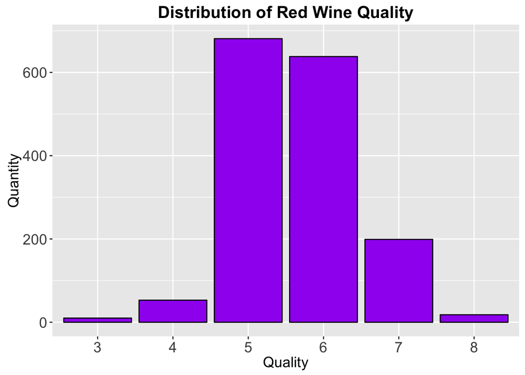

```
##   1   2   3   4   5   6   7   8   9  10
##   0   0  10  53 681 638 199  18   0   0
```

### Description One

The histogram shows the most frequent quality levels of red wine are 5 and 6. There is no perfect score of 9 or 10 for any of wines available in the dataset, as well as no lowest scores 1 or 2.

### Plot Two: Correlation Between Objective Parameters

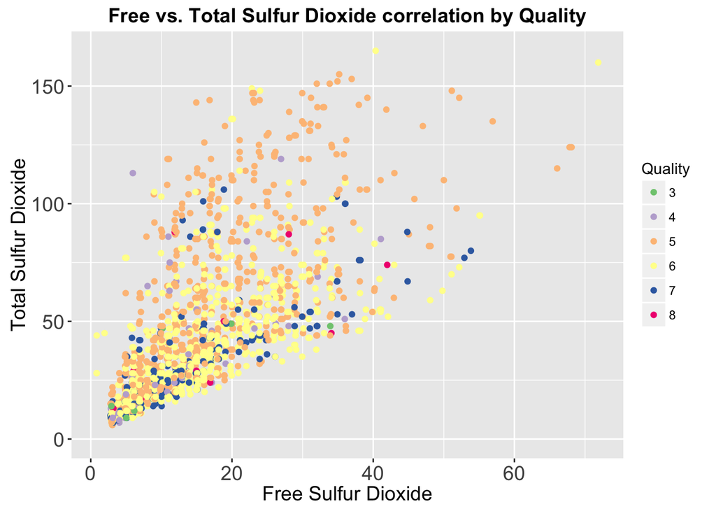

### Description Two

Free Sulfur Dioxide and Total Sulfur Dioxide variables show the strongest correlation among all wine parameters (see Spearman Rank Correlation table ) and it equals to 0.789. It seems that higher quality wines have less Total Sulfur Dioxide, most of the low quality wine is clustered in the upper portion of the graph, while high quality wine is around mid-left region.

### Plot Three: Distribution of Quality vs. Volatile Acidity

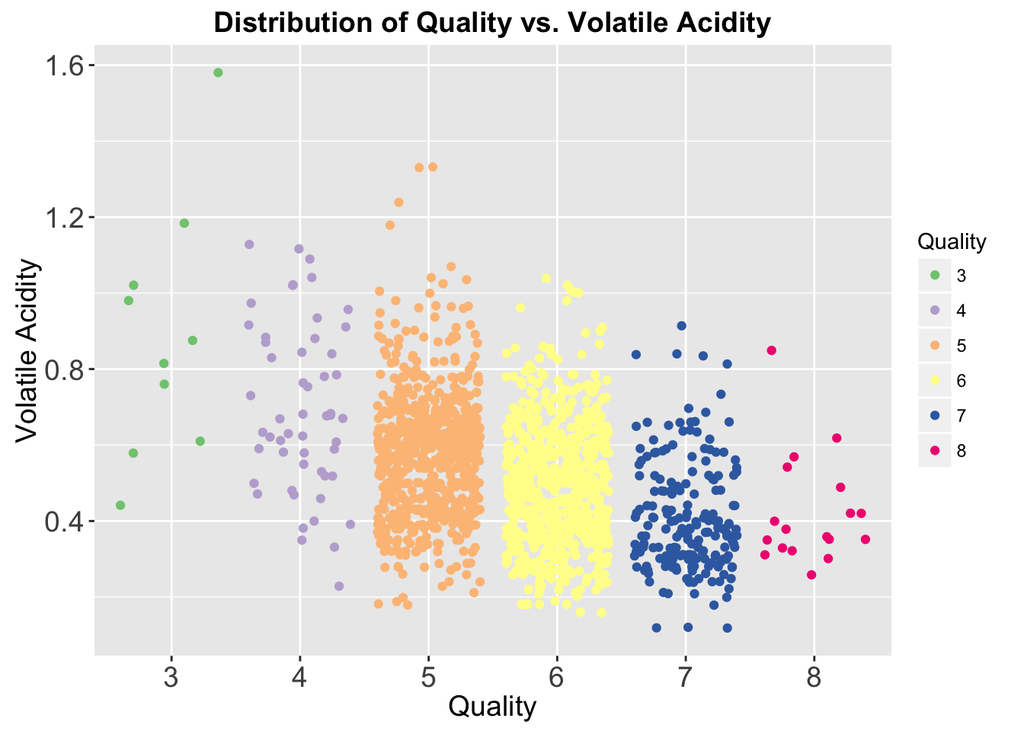

### Description Three

The volatile acidity of the wines is one of the best predictors of the quality. The clustering in the graph can be used to predict the quality of a red wine given volatile acidity value. The best qualities have lower levels of the volatile acidity.

# Reflection

In recent years, the interest in wine has increased, leading to growth of the wine industry. Producers are investing in new technologies to improve wine production and selling. Analyzing the data now is more important whenever.

After exploring and analyzing the data, I may conclude that tester decisions on wine quality levels are based on their personal testes. Only very few variables have strong correlation with quality of wine. It would have been more accurate results, if more data would have been available, such as country where the grape was grown, year of production, grape types, wine brand etc.